# lab5

Qinwen Yang, AngelQinwen

4/11/2019

```r
library(ggplot2)
library(dplyr)
library(tidyverse)
library(lubridate)
accident <- read.csv("https://raw.githubusercontent.com/xdaiISU/ds202materials/master/hwlabs/fars2017/accident.csv", stringsAsFactors = FALSE)
person <- read.csv("https://raw.githubusercontent.com/xdaiISU/ds202materials/master/hwlabs/fars2017/person.csv", stringsAsFactors = FALSE)
names(accident)
```

```
##  [1] "STATE"      "ST_CASE"    "VE_TOTAL"   "VE_FORMS"   "PVH_INVL"
##  [6] "PEDS"       "PERNOTMVIT" "PERMVIT"    "PERSONS"    "COUNTY"
## [11] "CITY"       "DAY"        "MONTH"      "YEAR"       "DAY_WEEK"
## [16] "HOUR"       "MINUTE"     "NHS"        "RUR_URB"    "FUNC_SYS"
## [21] "RD_OWNER"   "ROUTE"      "TWAY_ID"    "TWAY_ID2"   "MILEPT"
## [26] "LATITUDE"   "LONGITUD"   "SP_JUR"     "HARM_EV"    "MAN_COLL"
## [31] "RELJCT1"    "RELJCT2"    "TYP_INT"    "WRK_ZONE"   "REL_ROAD"
## [36] "LGT_COND"   "WEATHER1"   "WEATHER2"   "WEATHER"    "SCH_BUS"
## [41] "RAIL"       "NOT_HOUR"   "NOT_MIN"    "ARR_HOUR"   "ARR_MIN"
## [46] "HOSP_HR"    "HOSP_MN"    "CF1"        "CF2"        "CF3"
## [51] "FATALS"     "DRUNK_DR"
```

Part one: Accident Data

Q1: Are there some days of the week where more accidents happen than on others (use variable DAY_WEEK)?

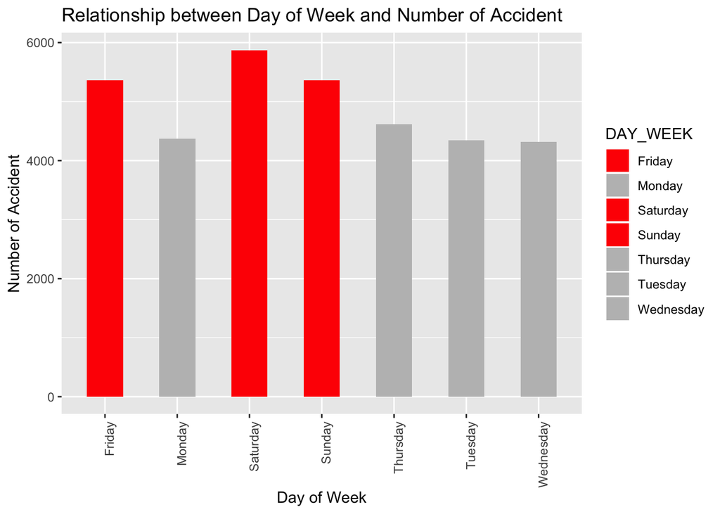

```r
Dayweek <- accident %>% group_by(DAY_WEEK) %>% summarise(n=n())
Dayweek$DAY_WEEK = as.factor(c("Sunday","Monday","Tuesday", "Wednesday", "Thursday", "Friday","Saturday"))
ggplot(Dayweek, aes(x=DAY_WEEK, y=n, fill=DAY_WEEK))+geom_bar(stat="identity", width = 0.5)+xlab('Day of Week')+ylab('Number of Accident')+ggtitle('Relationship between Day of Week and Number of Accident ')+ scale_fill_manual(values = c("red","grey","red","red","grey","grey","grey"))+theme(axis.text.x = element_text(angle=90, hjust=1))
```

Conclusion: From the bar plot, we can conclude that Friday, Saturday and Sunday of a week have more accidents happen than others.

Q2:What time of the day do accidents happen (use variable HOUR)?

```r
unique(accident$HOUR)
```

```
##  [1] 23 14 20 16 18 17  4 21  0  1  7 19  8 11  6 13  3  2  9  5 12 15 22
## [24] 10 99
```

```r
Hour24 <- accident %>% filter(HOUR <= 24)
(GroupHour <- Hour24 %>% group_by(HOUR) %>% summarise(n=n()))
```

```
## # A tibble: 24 x 2
##     HOUR     n
##    <int> <int>
##  1     0  1321
##  2     1  1177
##  3     2  1241
##  4     3   957
##  5     4   813
##  6     5  1065
##  7     6  1282
##  8     7  1162
##  9     8   945
## 10     9   929
## # … with 14 more rows
```

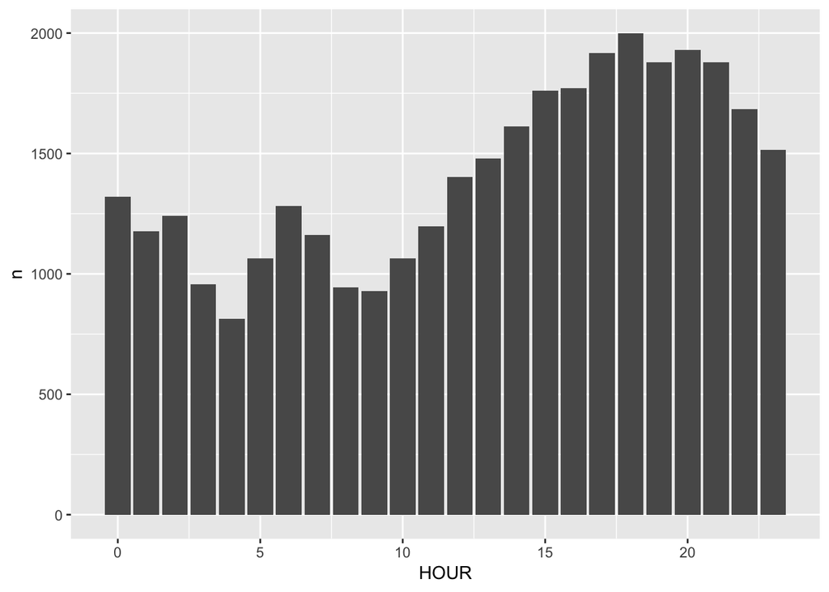

```r
ggplot(GroupHour, aes(x=HOUR, y=n))+geom_bar(stat = "identity")
```

Q3:What is the number of accidents with at least one drunk driver (use variable DRUNK_DR)?

```r
unique(accident$DRUNK_DR)
```

```
## [1] 0 1 2 3
```

```r
DrunkDri <- accident %>% filter(DRUNK_DR > 0 )
DrunkDri2 <- DrunkDri %>% group_by(DRUNK_DR) %>% summarise(n=n())
sum(DrunkDri2$n)
```

```
## [1] 8769
```

There are 8769 accidents with at least one drunk driver.

Part two: Connecting Data

Q1: Load the person table. Identify drivers (PER_TYP == 1, see fars manual) and subset on them.

```r
drivers <- person %>% filter(PER_TYP == 1)
```

Q2: Join accident and driver table (work out which variable(s) to use)

```r
library(dplyr)
DropHour <- drivers %>% select(-HOUR)
JoinTab <- inner_join(DropHour, accident, by=c("STATE", "ST_CASE"))
```

Q3: Tally the number of accidents by day of the week (DAY_WEEK), hour of the day (HOUR) and gender (SEX). Visualize the results!

```r
#Sum <- JoinTab %>% group_by()
unique(JoinTab$SEX)
```

```
## [1] 1 2 9 8
```

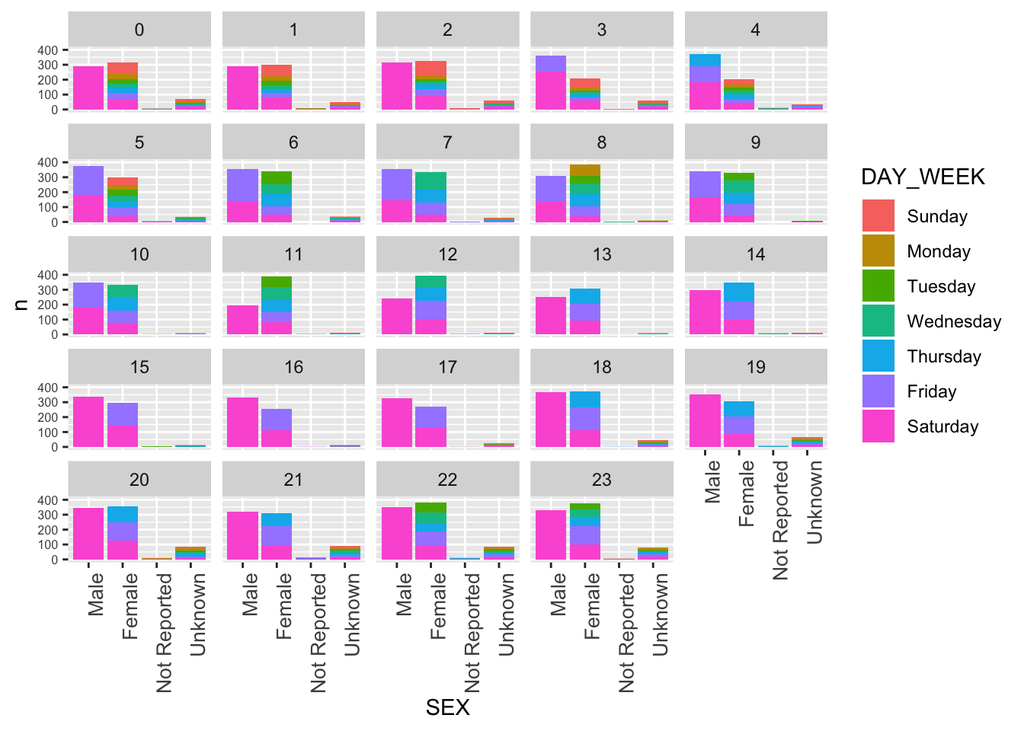

```r
JoinTab$SEX <- ifelse(JoinTab$SEX == 8, 3, JoinTab$SEX)
JoinTab$SEX <- ifelse(JoinTab$SEX == 9, 4, JoinTab$SEX)
JoinTab <- JoinTab %>% filter(HOUR <= 24)
#class(JoinTab$SEX)
JoinTab$SEX<-factor(JoinTab$SEX)
levels(JoinTab$SEX) <- c("Male", "Female", "Not Reported","Unknown")
#class(JoinTab$DAY_WEEK)
JoinTab$DAY_WEEK <- factor(JoinTab$DAY_WEEK)
levels(JoinTab$DAY_WEEK) <- c("Sunday","Monday","Tuesday","Wednesday", "Thursday","Friday","Saturday")
GroupJoinTab <- JoinTab %>% group_by(SEX, DAY_WEEK, HOUR) %>% summarise(n=n())
ggplot(GroupJoinTab, aes(x=SEX,y=n, fill=DAY_WEEK))+geom_bar(stat = "identity")+facet_wrap(~HOUR)+theme(axis.text.x = element_text(angle=90, hjust=1, size=10))+theme(axis.text=element_text(size=6))+ylim(c(0,400))
```

Conclusion: From the plot, most male get accident at Saturday of the week. At 8am in the morning, women are frequently get accident, and it cover a week.

Q1: Use readxl::read_xlsx to read in the GLCs

```r
#help(read_xlsx)
#str(GLCs)
GLCs <-  readxl::read_xlsx("FRPP GLC United States.xlsx", skip = 1)
```

Connecting Data and Make Maps: Q2: Now plot a choropleth map of accidents on a county level

```r
#Draft:ggplot(data=counties, aes(x=LONGITUD,y=LATITUDE ))+geom_polygon(aes(group=group,color=LATITUDE))+geom_point(data=accident, aes(x=LONGITUD, y=LATITUDE))+xlim(c(-171, 250))

#Create a counties variable for map data named county data frame
counties <- map_data('county')
#Rename counties long and lat to LONGITUD, LATITUDE
counties <- counties %>% rename(LONGITUD =long)
counties <- counties %>% rename(LATITUDE = lat)
#Create var accident1 to summarize number of accidents by each COUNTY
(accident1 <- accident %>% group_by(COUNTY,STATE) %>% summarise(`Number Of Accident`=n()))
```

```
## # A tibble: 2,840 x 3
## # Groups:   COUNTY [?]
##    COUNTY STATE `Number Of Accident`
##     <int> <int>                <int>
##  1      1     1                   14
##  2      1     4                   34
##  3      1     5                    3
##  4      1     6                   95
##  5      1     8                   60
##  6      1     9                   58
##  7      1    10                   19
##  8      1    11                   29
##  9      1    12                   47
## 10      1    13                    7
## # … with 2,830 more rows
```

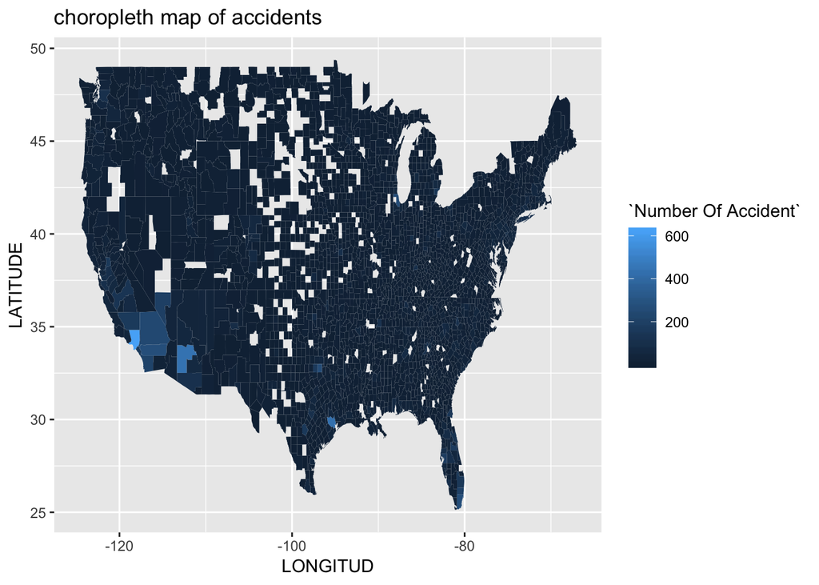

```r
#Rename GLCs `County Code` to COUNTY
GLCs <- GLCs %>% rename(COUNTY = `County Code`)
GLCs <- GLCs %>% rename(STATE = `State Code`)
#Change GLCs COUNTY type to numeric
GLCs$COUNTY <- as.numeric(GLCs$COUNTY)
GLCs$STATE <- as.numeric(GLCs$STATE)
#Create JoinTwo var to inner join two data frames GLCs and accident1 by COUNTY
JoinTwo <- inner_join(GLCs, accident1, by=c("COUNTY", "STATE"))
JoinTwo <- JoinTwo %>% select(-c(`Old City Name`, `Date Record Added`))
#Rename...
JoinTwo <- JoinTwo %>% rename(region = `State Name`)
#change JoinTwo region column to lower case
JoinTwo$region <- tolower(JoinTwo$region)
#Rename...
JoinTwo <- JoinTwo %>% rename(subregion = `County Name`)
#lower case
JoinTwo$subregion <- tolower(JoinTwo$subregion)
#Create car FinalJoin to inner join counties and JoinTwo by region and subregion
FinalJoin <- inner_join(counties, JoinTwo, by=c("region","subregion"))
#plot
ggplot(data = FinalJoin, aes(x=LONGITUD,y=LATITUDE))+geom_polygon(aes(group=group, fill=`Number Of Accident`))+ggtitle('choropleth map of accidents')
```

Q6: Can you find seasonal trends in accident occurrences in different states? Is summer or winter more dangerous? Why?

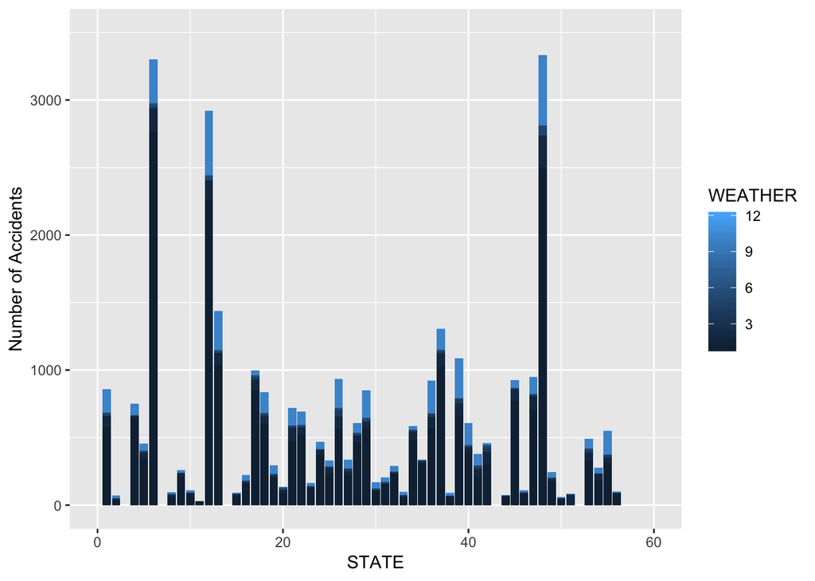

```r
accident <- accident %>% filter(WEATHER < 98)

Weather <- accident %>% group_by(STATE, WEATHER) %>% summarise(n=n())

ggplot(Weather, aes(x=STATE, y=n, fill=WEATHER))+geom_bar(stat = "identity")+xlim(c(0,60))+
  ylim(c(0, 3500))+ylab('Number of Accidents')
```